# XAI - MS 1 - EDA zbioru Heart Disease UCI

```python
import numpy as np
import pandas as pd
import seaborn as sns
import matplotlib.pyplot as plt
import warnings
warnings.filterwarnings('ignore')
```

## Wczytanie zbioru danych Heart Disease

Zbiór dotyczy zebranych danych od pacjentów szpitala, którzy mogą mieć chorobę serca, zajmiemy się analizą tych danych, aby sprawdzić czy i jak inne współczynniki zdrowia pływają na choroby serca.

Można go pobrać ze strony [kaggle](https://www.kaggle.com/ronitf/heart-disease-uci). Jednak zawierza on błędy, które różnią go od danych orginalnych z UCI, dlatego warto zająć się orginalnym zbiorem, który znajduje się na stronie [uci](https://archive.ics.uci.edu/ml/datasets/heart+disease).

```python
df  = pd.read_csv('processed.cleveland.data', header = None)
```

```python
df.head()
```

|  | 0 | 1 | 2 | 3 | 4 | 5 | 6 | 7 | 8 | 9 | 10 | 11 | 12 | 13 |
| --- | --- | --- | --- | --- | --- | --- | --- | --- | --- | --- | --- | --- | --- | --- |
| 0 | 63.0 | 1.0 | 1.0 | 145.0 | 233.0 | 1.0 | 2.0 | 150.0 | 0.0 | 2.3 | 3.0 | 0.0 | 6.0 | 0 |
| 1 | 67.0 | 1.0 | 4.0 | 160.0 | 286.0 | 0.0 | 2.0 | 108.0 | 1.0 | 1.5 | 2.0 | 3.0 | 3.0 | 2 |
| 2 | 67.0 | 1.0 | 4.0 | 120.0 | 229.0 | 0.0 | 2.0 | 129.0 | 1.0 | 2.6 | 2.0 | 2.0 | 7.0 | 1 |
| 3 | 37.0 | 1.0 | 3.0 | 130.0 | 250.0 | 0.0 | 0.0 | 187.0 | 0.0 | 3.5 | 3.0 | 0.0 | 3.0 | 0 |
| 4 | 41.0 | 0.0 | 2.0 | 130.0 | 204.0 | 0.0 | 2.0 | 172.0 | 0.0 | 1.4 | 1.0 | 0.0 | 3.0 | 0 |

```python
df.shape
```

```
(303, 14)
```

Orginalny zbiór nie posiada nazw kolumn, dlatego nadamy je ręcznie zgodnie z opisem zbioru.

```python
df.columns = ['age', 'sex', 'cp', 'trestbps', 'chol', 'fbs', 'restecg', 'thalach', 'exang', 'oldpeak', 'slope', 'ca', 'thal', 'target']
```

```python
df.head()
```

|  | age | sex | cp | trestbps | chol | fbs | restecg | thalach | exang | oldpeak | slope | ca | thal | target |
| --- | --- | --- | --- | --- | --- | --- | --- | --- | --- | --- | --- | --- | --- | --- |
| 0 | 63.0 | 1.0 | 1.0 | 145.0 | 233.0 | 1.0 | 2.0 | 150.0 | 0.0 | 2.3 | 3.0 | 0.0 | 6.0 | 0 |
| 1 | 67.0 | 1.0 | 4.0 | 160.0 | 286.0 | 0.0 | 2.0 | 108.0 | 1.0 | 1.5 | 2.0 | 3.0 | 3.0 | 2 |
| 2 | 67.0 | 1.0 | 4.0 | 120.0 | 229.0 | 0.0 | 2.0 | 129.0 | 1.0 | 2.6 | 2.0 | 2.0 | 7.0 | 1 |
| 3 | 37.0 | 1.0 | 3.0 | 130.0 | 250.0 | 0.0 | 0.0 | 187.0 | 0.0 | 3.5 | 3.0 | 0.0 | 3.0 | 0 |
| 4 | 41.0 | 0.0 | 2.0 | 130.0 | 204.0 | 0.0 | 2.0 | 172.0 | 0.0 | 1.4 | 1.0 | 0.0 | 3.0 | 0 |

## Ogólne zapoznanie się ze zbiorem

Mamy 13 kolumn objaśniających i target oznaczający posiadaną chorobę wieńcową serca.

Przyjrzyjmy się bliżej kolumnom:

```python
df.info()
```

```
<class 'pandas.core.frame.DataFrame'>
RangeIndex: 303 entries, 0 to 302
Data columns (total 14 columns):
 #   Column    Non-Null Count  Dtype
---  ------    --------------  -----
 0   age       303 non-null    float64
 1   sex       303 non-null    float64
 2   cp        303 non-null    float64
 3   trestbps  303 non-null    float64
 4   chol      303 non-null    float64
 5   fbs       303 non-null    float64
 6   restecg   303 non-null    float64
 7   thalach   303 non-null    float64
 8   exang     303 non-null    float64
 9   oldpeak   303 non-null    float64
 10  slope     303 non-null    float64
 11  ca        303 non-null    object
 12  thal      303 non-null    object
 13  target    303 non-null    int64
dtypes: float64(11), int64(1), object(2)
memory usage: 33.3+ KB
```

```python
df.isna().any()
```

```
age         False
sex         False
cp          False
trestbps    False
chol        False
fbs         False
restecg     False
thalach     False
exang       False
oldpeak     False
slope       False
ca          False
thal        False
target      False
dtype: bool
```

Nie posiadamy braków danych zakodowanych jako braki, więc jeśli nie mamy innaczej zakodowanych braków to mamy pełne 303 wiersze wypełnione danymi. Wszystkie dane są w postaci liczbowej poza ca i thal, które są kategoryczne. Tylko jakie mamy podane dane?

Wyjaśnienie oznaczeń:

- age - wiek w latach
- sex - płeć (1 = mężczyzna, 0 = kobieta)
- cp - rodzaj bólu w klatce piersiowej:
  - Wartość 1: typowa dławica piersiowa
  - Wartość 2: atypowa dławica piersiowa
  - Wartość 3: ból bez związku z dławicą piersiową
  - Wartość 4: bezobjawowa
- trestbps - spoczynkowe ciśnienie krwi (w mm Hg przy przyjęciu do szpitala)
- chol - surowica cholesterol w mg / dl
- fbs - poziom cukru we krwi na czczo> 120 mg / dl (1 = prawda, 0 = fałsz)
- restecg - spoczynkowe wyniki elektrokardiograficzne:
  - Wartość 0: normalna
  - Wartość 1: nieprawidłowości w załamku T lub odcinku ST (zmiany wskazujące na niedokrwienie mięśnia serca (okresu repolaryzacji))
  - Wartość 2: prawdopodobny przerost lewej komory (przerost mięśnia serca)
- thalach - maksymalne osiągnięte tętno
- exang - dławica wysiłkowa (1 = tak, 0 = nie)
- oldpeak - obniżenie ST wywołane wysiłkiem fizycznym w stosunku do odpoczynku („Segment ST” odnosi się do wzoru, który pojawia się na elektrokardiogramie, który jest obrazem bicia serca.)
- slope - nachylenie szczytu ćwiczeń odcinka ST:
  - Wartość 1: malejąco
  - Wartość 2: płaska
  - Wartość 3: rosnąco
- ca - liczba głównych naczyń (0-3) zabarwionych podczas uwapnienia
- thal - 3 = normalny; 6 = naprawiona wada; 7 = odwracalna wada
- target:
  - Value 0: chory/zdrowy ze zwężoeniem < 50% bez choroby wieńcowej (0).
  - Value 1: chory ze zwężeniem > 50% to chory z chorobą wieńcową (1)

## Propocje w zmiennej objaśnianej

Zobaczmy, czy rozkład osób posiadających chorobę serca do tych co jej nie mają jest w zbiorze w miarę równomierny.

```python
print(df.target.value_counts())
```

```
0    164
1     55
2     36
3     35
4     13
Name: target, dtype: int64
```

Mamy 5 a nie 2 klasy w targecie, ponieważ liczby od 1 do 4 są stopniami zwężenia i choroby wieńcowej. Opis zbioru zakłada tylko dwie klasy, dlatego połączymy je, aby to uzyskać.

```python
df.target = df.target.replace(2,1)
df.target = df.target.replace(3,1)
df.target = df.target.replace(4,1)
```

```python
print(df.target.value_counts())
```

```
0    164
1    139
Name: target, dtype: int64
```

Osób z chorobą wieńcową jest mniej, jednak nie są to duże różnice.

```python
countNoDisease = len(df[df.target == 0])
countHaveDisease = len(df[df.target == 1])
print('Procent pacjentów nie posiadających choroby serca: {:.2f}%'.format((countNoDisease / (len(df.target))*100)))
print('Procent pacjentów posiadających chorobę serca: {:.2f}%'.format((countHaveDisease / (len(df.target))*100)))
```

```
Procent pacjentów nie posiadających choroby serca: 54.13%
Procent pacjentów posiadających chorobę serca: 45.87%
```

Nie jest to duża różnica - niecałe 46% osób posiada CAD (chorobę wieńcową), natomiast trochę ponad 54% nie posiada.

## Zbiorowe statystyki

Poniżej mamy niektóre statystyki dla wszystkich kolumn w danych.

```python
df.describe().applymap("{0:.1f}".format)
```

|  | age | sex | cp | trestbps | chol | fbs | restecg | thalach | exang | oldpeak | slope | target |
| --- | --- | --- | --- | --- | --- | --- | --- | --- | --- | --- | --- | --- |
| count | 303.0 | 303.0 | 303.0 | 303.0 | 303.0 | 303.0 | 303.0 | 303.0 | 303.0 | 303.0 | 303.0 | 303.0 |
| mean | 54.4 | 0.7 | 3.2 | 131.7 | 246.7 | 0.1 | 1.0 | 149.6 | 0.3 | 1.0 | 1.6 | 0.5 |
| std | 9.0 | 0.5 | 1.0 | 17.6 | 51.8 | 0.4 | 1.0 | 22.9 | 0.5 | 1.2 | 0.6 | 0.5 |
| min | 29.0 | 0.0 | 1.0 | 94.0 | 126.0 | 0.0 | 0.0 | 71.0 | 0.0 | 0.0 | 1.0 | 0.0 |
| 25% | 48.0 | 0.0 | 3.0 | 120.0 | 211.0 | 0.0 | 0.0 | 133.5 | 0.0 | 0.0 | 1.0 | 0.0 |
| 50% | 56.0 | 1.0 | 3.0 | 130.0 | 241.0 | 0.0 | 1.0 | 153.0 | 0.0 | 0.8 | 2.0 | 0.0 |
| 75% | 61.0 | 1.0 | 4.0 | 140.0 | 275.0 | 0.0 | 2.0 | 166.0 | 1.0 | 1.6 | 2.0 | 1.0 |
| max | 77.0 | 1.0 | 4.0 | 200.0 | 564.0 | 1.0 | 2.0 | 202.0 | 1.0 | 6.2 | 3.0 | 1.0 |

Część zmiennych jest kategoryczna, ale zakodowana jako liczby, dlatego poniżej wybraliśmy tylko zmienne, które z opisu wiemy, że są numeryczne i dla nich sprawdziliśmy średnią względem targetu.

```python
df.loc[:,['age', 'trestbps', 'chol', 'thalach', 'oldpeak', 'slope', 'target']].groupby('target').mean()
```

| target | age | trestbps | chol | thalach | oldpeak | slope |
| --- | --- | --- | --- | --- | --- | --- |
| 0 | 52.585366 | 129.250000 | 242.640244 | 158.378049 | 0.586585 | 1.408537 |
| 1 | 56.625899 | 134.568345 | 251.474820 | 139.258993 | 1.574101 | 1.827338 |

I tak średnie maksymalne tętno dla osób z CAD jest mniejsze niż dla osób zdrowych, natomiast mamy średnio większe obniżenie linii bicia serca na wynikach EKG po wysiłku fizyczny oraz wiek, cholesterol, spoczynkowe ćiśnienie krwi.

Jednak może to zależeć od ilości danych z określonych przedziałów, dlatego warto się przyjrzeć tym danym całościowo zanim wyciągniemy wnioski.

## Wizualizacje rozkładów zmiennych

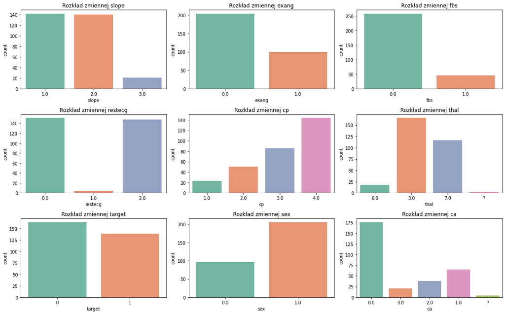

```python
variables=list(set(list(df.columns))-set(['age', 'trestbps', 'chol', 'thalach', 'oldpeak']))

f, axes=plt.subplots(3, 3, figsize=(16, 10))

for i in range(0, len(variables)):
    sns.countplot(data=df, x=variables[i], palette='Set2', ax=axes[i//3, i%3]).set_title('Rozkład zmiennej '+ variables[i])
plt.tight_layout();
```

Co możemy zauważyć:

- mamy więcej mężczyzn od kobiet danych
- to co już wiemy - mniej jest osób z CAD niż bez
- większość osób nie miała/ma dławicy wysiłkowej
- większość osób ma mniejszy poziom cukru we krwi niż 120 mg / dl (czyli nie ma cukrzycy)

Ciekawe rzeczy:

- kolumna **ca** miała mieć wyniki od 0 do 3, a pojawiło się '?, która oznacza NULL
- kolumna **thal** powinna mieć wartości 3,6,7 a tam również pojawia się '?', czyli NULL

Możliwe, że te dwie kolumny, które oznaczają specyficzne badania (uwapnienie czy sprawdzanie wad serca talem). A więc mamy **braki danych**!

```python
df[(df.ca == '?')|(df.thal == '?')]
```

|  | age | sex | cp | trestbps | chol | fbs | restecg | thalach | exang | oldpeak | slope | ca | thal | target |
| --- | --- | --- | --- | --- | --- | --- | --- | --- | --- | --- | --- | --- | --- | --- |
| 87 | 53.0 | 0.0 | 3.0 | 128.0 | 216.0 | 0.0 | 2.0 | 115.0 | 0.0 | 0.0 | 1.0 | 0.0 | ? | 0 |
| 166 | 52.0 | 1.0 | 3.0 | 138.0 | 223.0 | 0.0 | 0.0 | 169.0 | 0.0 | 0.0 | 1.0 | ? | 3.0 | 0 |
| 192 | 43.0 | 1.0 | 4.0 | 132.0 | 247.0 | 1.0 | 2.0 | 143.0 | 1.0 | 0.1 | 2.0 | ? | 7.0 | 1 |
| 266 | 52.0 | 1.0 | 4.0 | 128.0 | 204.0 | 1.0 | 0.0 | 156.0 | 1.0 | 1.0 | 2.0 | 0.0 | ? | 1 |
| 287 | 58.0 | 1.0 | 2.0 | 125.0 | 220.0 | 0.0 | 0.0 | 144.0 | 0.0 | 0.4 | 2.0 | ? | 7.0 | 0 |
| 302 | 38.0 | 1.0 | 3.0 | 138.0 | 175.0 | 0.0 | 0.0 | 173.0 | 0.0 | 0.0 | 1.0 | ? | 3.0 | 0 |

Jest to sześciu pacjentów. Dane można wyrzucić bądź uzupełnić. Przy takim małym zbiorze lepiej nie usuwać danych, więc trzeba zastosować imputację.

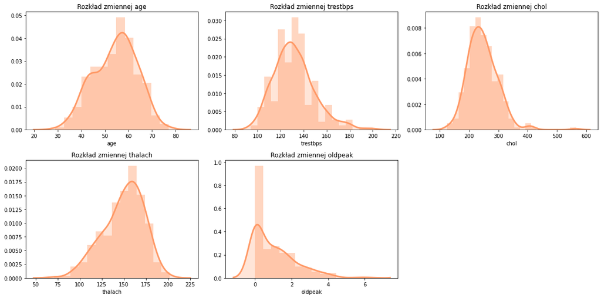

```python
variables=['age', 'trestbps', 'chol', 'thalach', 'oldpeak']

f, axes = plt.subplots(2, 3, figsize=(16, 8))

for i in range(0, len(variables)):
    sns.distplot(df[variables[i]], hist=True, kde=True, kde_kws={'shade': True, 'linewidth': 3}, ax=axes[i//3, i%3], color='#ff9966').set_title('Rozkład zmiennej '+ variables[i])
f.delaxes(axes[1, 2])
plt.tight_layout();
```

Co możemy zauważyć:

- ludzie trafiają do szpitala dopiero po 30 z powodu serca, najwięcej jest w okolicach 60 roku życia
- zalecana wartość spoczynkowego ciśnienia krwi to nie więcej niż 140, natomiast mamy sporo osób powyżej tej wartości. Na niektórych portalach zdrowotnych można spotkać się z taką klasyfikacją:
  - Nadciśnienie tętnicze 1. stopnia: 140 - 159 mm Hg / 90 - 99 mm Hg
  - Nadciśnienie tętnicze 2. stopnia: 160 - 179 mm Hg / 100 - 109 mm Hg
  - Nadciśnienie tętnicze 3. stopnia: ≥ 180 mm Hg / ≥ 110 mm Hg
- norma cholesterolu to do 190/200, natomiast u nas wartości są sporo większe, a takie od ok. 300 mogą oznaczać występowanie hipercholesterolemii, jeśli wartości są bardzo duże to możliwe, że występuje miażdżyca.
- maksymalne tętno pacjentów przeważnie znajduje się w przedziale 145-175, co ważne często maksymalne tętno zależy od wieku, stąd im niższe tym mamy pewnie ludzi starszych bądź chorych, ponieważ szybciej kończą oni próbę wysiłkową i wychodzi im niższe tętno
- najwięcej osób ma obniżenie ST po wysiłku fizycznym względem spoczynku dość małe, gdzie duże może oznaczać niedokrwistość i prowadzić do zgonów z powodu serca (aczkolwiek EKG jest wykonywane w danej chwili bicia serca i nie jest dobrym ostatecznym wyznacznikiem choroby)

```python
df[df.thalach < 100]
```

|  | age | sex | cp | trestbps | chol | fbs | restecg | thalach | exang | oldpeak | slope | ca | thal | target |
| --- | --- | --- | --- | --- | --- | --- | --- | --- | --- | --- | --- | --- | --- | --- |
| 72 | 62.0 | 1.0 | 4.0 | 120.0 | 267.0 | 0.0 | 0.0 | 99.0 | 1.0 | 1.8 | 2.0 | 2.0 | 7.0 | 1 |
| 114 | 62.0 | 0.0 | 3.0 | 130.0 | 263.0 | 0.0 | 0.0 | 97.0 | 0.0 | 1.2 | 2.0 | 1.0 | 7.0 | 1 |
| 154 | 64.0 | 1.0 | 4.0 | 120.0 | 246.0 | 0.0 | 2.0 | 96.0 | 1.0 | 2.2 | 3.0 | 1.0 | 3.0 | 1 |
| 175 | 57.0 | 1.0 | 4.0 | 152.0 | 274.0 | 0.0 | 0.0 | 88.0 | 1.0 | 1.2 | 2.0 | 1.0 | 7.0 | 1 |
| 223 | 53.0 | 1.0 | 4.0 | 123.0 | 282.0 | 0.0 | 0.0 | 95.0 | 1.0 | 2.0 | 2.0 | 2.0 | 7.0 | 1 |
| 244 | 60.0 | 0.0 | 3.0 | 120.0 | 178.0 | 1.0 | 0.0 | 96.0 | 0.0 | 0.0 | 1.0 | 0.0 | 3.0 | 0 |
| 245 | 67.0 | 1.0 | 4.0 | 120.0 | 237.0 | 0.0 | 0.0 | 71.0 | 0.0 | 1.0 | 2.0 | 0.0 | 3.0 | 1 |
| 296 | 59.0 | 1.0 | 4.0 | 164.0 | 176.0 | 1.0 | 2.0 | 90.0 | 0.0 | 1.0 | 2.0 | 2.0 | 6.0 | 1 |

Widzimy, że wszystkie te osoby są powyżej 50 roku życia.

## Zmienne objaśniające względem targetu

### 1. Płeć

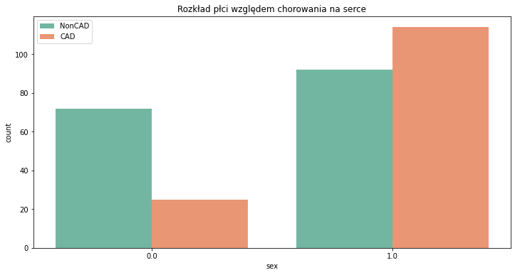

```python
f, axes = plt.subplots(1, 1, figsize=(12, 6))
sns.countplot(x='sex',hue='target',data=df, palette='Set2').set_title('Rozkład płci względem chorowania na serce')
plt.legend(["NonCAD", "CAD"])
plt.plot();
```

```python
countFemale = len(df[df.sex == 0])
countMale = len(df[df.sex == 1])
print("Procent kobiet wśród pacjentów: {:.2f}%".format((countFemale / (len(df.sex))*100)))
print("Procent mężczyzn wśród pacjentów: {:.2f}%".format((countMale / (len(df.sex))*100)))
```

```
Procent kobiet wśród pacjentów: 32.01%
Procent mężczyzn wśród pacjentów: 67.99%
```

Jak widać to więcej mężczyzn choruje częściej na serce.

### 2. Wiek

```python
df.age = df.age.astype('int64')
```

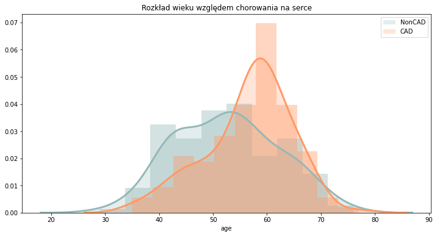

```python
f, axes = plt.subplots(1, 1, figsize=(12, 6))
sns.distplot(df[df.target==0].age, hist=True, kde=True, kde_kws={'shade': True, 'linewidth': 3}, color='#94b8b8').set_title('Rozkład wieku względem chorowania na serce')
sns.distplot(df[df.target==1].age, hist=True, kde=True, kde_kws={'shade': True, 'linewidth': 3}, color='#ff9966').set_title('Rozkład wieku względem chorowania na serce')
plt.legend(["NonCAD", "CAD"])
plt.plot();
```

Większość pacjentów jest po 50 i to oni częściej chorują, co oczywiste, że z wiekiem pojawia się więcej problemów zdrowotnych, w tym choroby serca.

### 3. Ból w klatce

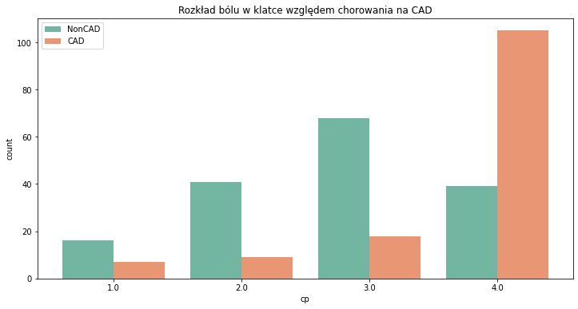

```python
f, axes = plt.subplots(1, 1, figsize=(12, 6))
sns.countplot(x='cp',hue='target',data=df, palette='Set2').set_title('Rozkład bólu w klatce względem chorowania na CAD')
plt.legend(["NonCAD", "CAD"])
plt.plot();
```

Przewaga chorych na CAD znajduje się w 4 kategorii, która oznacza bezobjawowy, czyli brak bólu. To daj do myślenia, ponieważ osoby chore na CAD powinny mieć ból w klatce.

Poniżej załączono tabelkę badania PTP. Na podstawie takiej tabeli możemy szacować prawdopodobieństwo choroby wieńcowej. Jeśli PTP wynosi < 15 % to choroba wieńcowa jest mało prawdopodobna, jeśli >85 % pewna. W tych zakresach nie ma sensu wykonywać diagnostyki. Gupa między 15-65% może mieć badanie nieinwazyjne do diagnostyki CAD a grupa 65-84 powinna mieć wykonaną diagnostykę funkcjonalną.

Na podstawie tabeli możemy uznawać, że kodowanie się nie zgadza. Osoby z typical angina powinnym mieć przewagę w chorobie, więc możemy się zastanawiać czy kolumna 1 nie została zamieniona z 4. Tym bardziej, że na kaggle są one tak przedstawione.

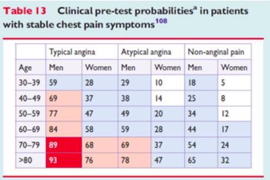

### 5. Tętno maksymalne

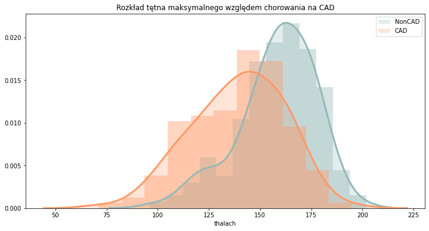

```python
f, axes = plt.subplots(1, 1, figsize=(12, 6))
sns.distplot(df[df.target==0].thalach, hist=True, kde=True, kde_kws={'shade': True, 'linewidth': 3}, color='#94b8b8').set_title('Rozkład tętna maksymalnego względem chorowania na CAD')
sns.distplot(df[df.target==1].thalach, hist=True, kde=True, kde_kws={'shade': True, 'linewidth': 3}, color='#ff9966').set_title('Rozkład tętna maksymalnego względem chorowania na CAD')
plt.legend(["NonCAD", "CAD"])
plt.plot();
```

### 4. Wady serca (thal)

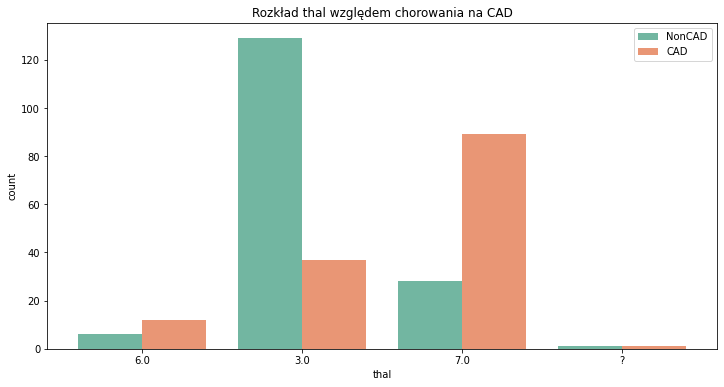

```python
f, axes = plt.subplots(1, 1, figsize=(12, 6))
sns.countplot(x='thal',hue='target',data=df, palette='Set2').set_title('Rozkład thal względem chorowania na CAD')
plt.legend(["NonCAD", "CAD"])
plt.plot();
```

Widzimy, że zdrowi ludzie w większości mają brak wady, natomiast chorzy najczęściej posiadają wadę odwracalną.

### 5. Ca

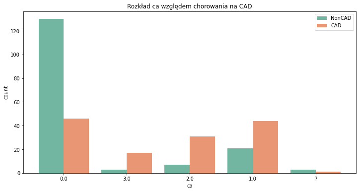

```python
f, axes = plt.subplots(1, 1, figsize=(12, 6))
sns.countplot(x='ca',hue='target',data=df, palette='Set2').set_title('Rozkład ca względem chorowania na CAD')
plt.legend(["NonCAD", "CAD"])
plt.plot();
```

Im więcej naczyń zabarwionych tym mniej osób zdrowych.

## Zależności między zmiennymi objaśniającymi

### 1. Wykresy dla wieku i cholesterolu oraz wieku i tętna

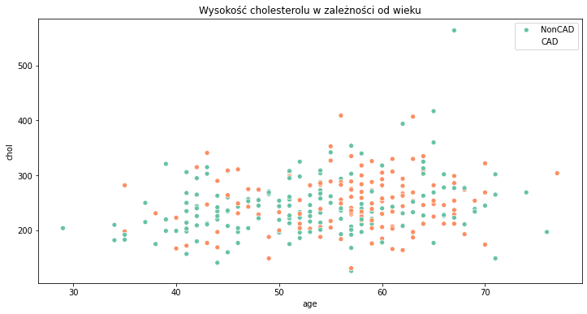

```python
f, axes = plt.subplots(1, 1, figsize=(12, 6))
sns.scatterplot(x='age', y='chol', hue='target',data=df, palette='Set2').set_title('Wysokość cholesterolu w zależności od wieku')
plt.legend(["NonCAD", "CAD"])
plt.plot();
```

```python
df[df.chol > 500]
```

|  | age | sex | cp | trestbps | chol | fbs | restecg | thalach | exang | oldpeak | slope | ca | thal | target |
| --- | --- | --- | --- | --- | --- | --- | --- | --- | --- | --- | --- | --- | --- | --- |
| 152 | 67 | 0.0 | 3.0 | 115.0 | 564.0 | 0.0 | 2.0 | 160.0 | 0.0 | 1.6 | 2.0 | 0.0 | 7.0 | 0 |

Jest to kobieta w wieku 67 lat, ma naprawdę duży cholestelor, jakiś rodzaj bólu w klatce, ale nie związanymi z dławicą, do tego ma złe wyniki serca, ale brak zwężeń naczyń głównych oraz brak cukrzycy czy dławicy wysiłkowej. Target określa jedynie chorobę wieńcową, więc może posiada inną chorobę serca.

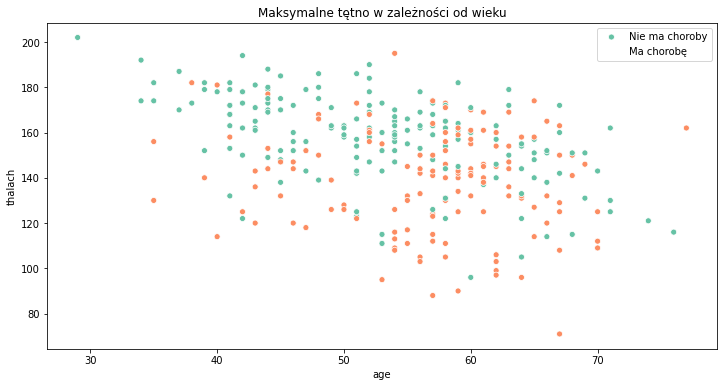

```python
f, axes = plt.subplots(1, 1, figsize=(12, 6))
sns.scatterplot(x='age', y='thalach', hue='target',data=df, palette='Set2').set_title('Maksymalne tętno w zależności od wieku')
plt.legend(["Nie ma choroby", "Ma chorobę"])
plt.plot();
```

Tutaj również mamy jedną rzucającą się w oczy wartość - osoba przed 30 bez CAD i bardzo wysokim tętnem maksymalnym. Przyjrzyjmy się temu pacjnetowi:

```python
df[df.thalach > 200]
```

|  | age | sex | cp | trestbps | chol | fbs | restecg | thalach | exang | oldpeak | slope | ca | thal | target |
| --- | --- | --- | --- | --- | --- | --- | --- | --- | --- | --- | --- | --- | --- | --- |
| 132 | 29 | 1.0 | 2.0 | 130.0 | 204.0 | 0.0 | 2.0 | 202.0 | 0.0 | 0.0 | 1.0 | 0.0 | 3.0 | 0 |

```python
sA = df.groupby(['sex','age'])['target'].count().reset_index().sort_values(by='target',ascending=False)
sA.head(10).style.background_gradient(cmap='vlag')
```

|  | sex | age | target |
| --- | --- | --- | --- |
| 59 | 1.000000 | 58 | 13 |
| 58 | 1.000000 | 57 | 13 |
| 60 | 1.000000 | 59 | 13 |
| 53 | 1.000000 | 52 | 12 |
| 55 | 1.000000 | 54 | 11 |
| 45 | 1.000000 | 44 | 9 |
| 57 | 1.000000 | 56 | 8 |
| 52 | 1.000000 | 51 | 8 |
| 65 | 1.000000 | 64 | 7 |
| 24 | 0.000000 | 62 | 7 |

```python
sCp = df.groupby(['sex' , 'thal'])['target'].count().reset_index().sort_values(by='target' , ascending=False)
sCp.head(10).style.background_gradient(cmap='vlag')
```

|  | sex | thal | target |
| --- | --- | --- | --- |
| 6 | 1.000000 | 7.0 | 102 |
| 4 | 1.000000 | 3.0 | 86 |
| 0 | 0.000000 | 3.0 | 80 |
| 5 | 1.000000 | 6.0 | 17 |
| 2 | 0.000000 | 7.0 | 15 |
| 1 | 0.000000 | 6.0 | 1 |
| 3 | 0.000000 | ? | 1 |
| 7 | 1.000000 | ? | 1 |

```python
sChol = df.groupby(['sex' , 'chol'])['target'].count().reset_index().sort_values(by='target' , ascending=False)
sChol.head(10).style.background_gradient(cmap='vlag')
```

|  | sex | chol | target |
| --- | --- | --- | --- |
| 115 | 1.000000 | 212.000000 | 5 |
| 172 | 1.000000 | 282.000000 | 4 |
| 109 | 1.000000 | 204.000000 | 4 |
| 48 | 0.000000 | 269.000000 | 4 |
| 135 | 1.000000 | 234.000000 | 4 |
| 134 | 1.000000 | 233.000000 | 4 |
| 150 | 1.000000 | 254.000000 | 4 |
| 141 | 1.000000 | 243.000000 | 3 |
| 140 | 1.000000 | 240.000000 | 3 |
| 139 | 1.000000 | 239.000000 | 3 |

```python
sT = df.groupby(['sex' , 'trestbps'])['target'].count().reset_index().sort_values(by='target' , ascending=False)
sT.head(10).style.background_gradient(cmap='vlag')
```

|  | sex | trestbps | target |
| --- | --- | --- | --- |
| 47 | 1.000000 | 120.000000 | 27 |
| 55 | 1.000000 | 130.000000 | 24 |
| 61 | 1.000000 | 140.000000 | 22 |
| 41 | 1.000000 | 110.000000 | 16 |
| 15 | 0.000000 | 130.000000 | 12 |
| 51 | 1.000000 | 125.000000 | 11 |
| 10 | 0.000000 | 120.000000 | 10 |
| 67 | 1.000000 | 150.000000 | 10 |
| 21 | 0.000000 | 140.000000 | 10 |
| 53 | 1.000000 | 128.000000 | 9 |

```python
sF = df.groupby(['sex' , 'fbs'])['target'].count().reset_index().sort_values(by='target' , ascending=False)
sF.head(10).style.background_gradient(cmap='vlag')
```

|  | sex | fbs | target |
| --- | --- | --- | --- |
| 2 | 1.000000 | 0.000000 | 173 |
| 0 | 0.000000 | 0.000000 | 85 |
| 3 | 1.000000 | 1.000000 | 33 |
| 1 | 0.000000 | 1.000000 | 12 |

### Macierz korelacji zmiennych

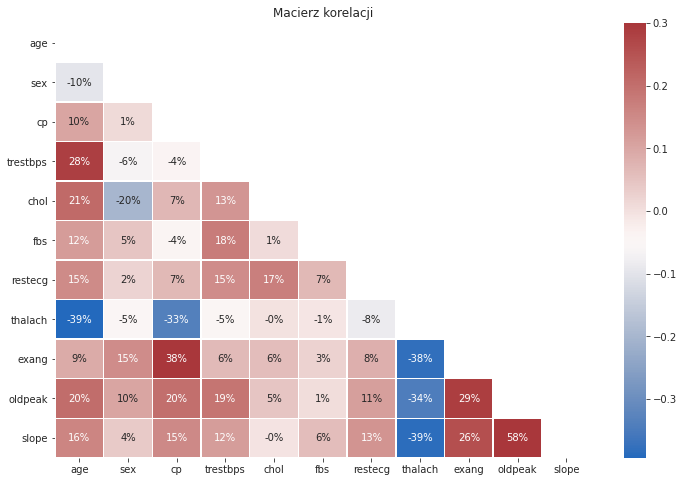

```python
mask = np.zeros_like(df.drop(columns=['target']).corr())
mask[np.triu_indices_from(mask)] = True
with sns.axes_style('ticks'):
    f, ax = plt.subplots(figsize=(12,8))
    ax = sns.heatmap(df.drop(columns=['target']).corr(), mask=mask, vmax=.3,annot=True,fmt=".0%",linewidth=0.5,square=False,cmap='vlag')
    plt.title('Macierz korelacji')
```

Wnioski:

- największą korelację dodatnią mamy między **oldpeak** a **slope**, co nie dziwi, bo dotyczą tego samego badania.
- dość dużą korelację dodatnią mamy też między **exang** i **cp**, które dotyczą bólu w klatce.
- największą korelację ujemną mamy dla **age** i **thalach**, co oznacza, że maksymalne tętno jest zależne od wieku i jest to prawda, bo dla wieku oblicza się wysokość tętna.